# Machine Learning: Data Preparation and KNN

**Please refer to** [Jupyter NBExtension Readme page](https://jupyter-contrib-nbextensions.readthedocs.io/en/latest/nbextensions/toc2/README.html) **to display**  
**the table of contents in floating window and expand the body of the contents.**

# Question 1 - Data Preprocessing

For this question, we need to perform all data preprocessing steps on a dataset on the UCI ML Datasets Repository so that the clean dataset can be directly fed into any classification algorithm within the Scikit-Learn Python module without any further changes.

This dataset is the Credit Approval data at the following address:

https://archive.ics.uci.edu/ml/datasets/Credit+Approval

The UCI Repository provides four datasets, but only two of them will be relevant:

- Assignment1_Q1_crx.names: Some basic info on the dataset together with the feature names & values
- Assignment1_Q1_crx.data: The actual data in comma-separated format

## 1. Import all necessary packages:

numpy, pandas, matplotlib and statistics

```python
import pandas as pd
import numpy as np
import matplotlib.pyplot as plt
import statistics as stat

%matplotlib inline
```

## 2. Read in the given data file

Read in `Assignment1_Q1_crx.data` and assign the column names as described in the file `Assignment1_Q1_crx.names`

```python
crx_colunm = list(map(str, range(1, 17)))
crx_colunm = ['A' + sub for sub in crx_colunm]
Data = pd.read_csv("Assignment1_Q1_crx.data", names=crx_colunm, index_col=False, header = None)
```

## 3. Show the read-in file

Display the first 5 rows in the dataset

```python
Data.head()
```

|  | A1 | A2 | A3 | A4 | A5 | A6 | A7 | A8 | A9 | A10 | A11 | A12 | A13 | A14 | A15 | A16 |
| --- | --- | --- | --- | --- | --- | --- | --- | --- | --- | --- | --- | --- | --- | --- | --- | --- |
| 0 | b | 30.83 | 0.000 | u | g | w | v | 1.25 | t | t | 1 | f | g | 00202 | 0 | + |
| 1 | a | 58.67 | 4.460 | u | g | q | h | 3.04 | t | t | 6 | f | g | 00043 | 560 | + |
| 2 | a | 24.50 | 0.500 | u | g | q | h | 1.50 | t | f | 0 | f | g | 00280 | 824 | + |
| 3 | b | 27.83 | 1.540 | u | g | w | v | 3.75 | t | t | 5 | t | g | 00100 | 3 | + |
| 4 | b | 20.17 | 5.625 | u | g | w | v | 1.71 | t | f | 0 | f | s | 00120 | 0 | + |

## 4. Check dimension and data types

```python
print(Data.shape)
print(Data.dtypes)
```

```
(690, 16)
A1      object
A2      object
A3     float64
A4      object
A5      object
A6      object
A7      object
A8     float64
A9      object
A10     object
A11      int64
A12     object
A13     object
A14     object
A15      int64
A16     object
dtype: object
```

## 5. Handling Numerical Descriptive features

According to the file ,`Assignment1_Q1_crx.names` feature `A2` and `A14` should be numeric and continuous. Covert these 2 features to numeric and transform the non-numeric values into NaN.

```python
Data['A2']=Data['A2'].apply(pd.to_numeric, errors='coerce')
Data['A14']=Data['A14'].apply(pd.to_numeric, errors='coerce')
```

Check whether there is any null values in the dataset. NaN values will also return True with the `isnull()` function

```python
Data.isnull().sum()
```

```
A1      0
A2     12
A3      0
A4      0
A5      0
A6      0
A7      0
A8      0
A9      0
A10     0
A11     0
A12     0
A13     0
A14    13
A15     0
A16     0
dtype: int64
```

There are only Null or NAN values in feature `A2` and `A14`. Locate the rows in these 2 features with NaN or Null values. For feature `A2`, at index=83, we found the first row with NaN value, for feature `A14`, at index=71, we found the first row with NaN value.

```python
Data.loc[Data['A2'].isnull()]
```

|  | A1 | A2 | A3 | A4 | A5 | A6 | A7 | A8 | A9 | A10 | A11 | A12 | A13 | A14 | A15 | A16 |
| --- | --- | --- | --- | --- | --- | --- | --- | --- | --- | --- | --- | --- | --- | --- | --- | --- |
| 83 | a | NaN | 3.500 | u | g | d | v | 3.000 | t | f | 0 | t | g | 300.0 | 0 | - |
| 86 | b | NaN | 0.375 | u | g | d | v | 0.875 | t | f | 0 | t | s | 928.0 | 0 | - |
| 92 | b | NaN | 5.000 | y | p | aa | v | 8.500 | t | f | 0 | f | g | 0.0 | 0 | - |
| 97 | b | NaN | 0.500 | u | g | c | bb | 0.835 | t | f | 0 | t | s | 320.0 | 0 | - |
| 254 | b | NaN | 0.625 | u | g | k | v | 0.250 | f | f | 0 | f | g | 380.0 | 2010 | - |
| 286 | a | NaN | 1.500 | u | g | ff | ff | 0.000 | f | t | 2 | t | g | 200.0 | 105 | - |
| 329 | b | NaN | 4.000 | y | p | i | v | 0.085 | f | f | 0 | t | g | 411.0 | 0 | - |
| 445 | a | NaN | 11.250 | u | g | ff | ff | 0.000 | f | f | 0 | f | g | NaN | 5200 | - |
| 450 | b | NaN | 3.000 | y | p | i | bb | 7.000 | f | f | 0 | f | g | 0.0 | 1 | - |
| 500 | b | NaN | 4.000 | u | g | x | v | 5.000 | t | t | 3 | t | g | 290.0 | 2279 | + |
| 515 | b | NaN | 10.500 | u | g | x | v | 6.500 | t | f | 0 | f | g | 0.0 | 0 | + |
| 608 | b | NaN | 0.040 | y | p | d | v | 4.250 | f | f | 0 | t | g | 460.0 | 0 | - |

```python
Data.loc[Data['A14'].isnull()]
```

|  | A1 | A2 | A3 | A4 | A5 | A6 | A7 | A8 | A9 | A10 | A11 | A12 | A13 | A14 | A15 | A16 |
| --- | --- | --- | --- | --- | --- | --- | --- | --- | --- | --- | --- | --- | --- | --- | --- | --- |
| 71 | b | 34.83 | 4.000 | u | g | d | bb | 12.500 | t | f | 0 | t | g | NaN | 0 | - |
| 202 | b | 24.83 | 2.750 | u | g | c | v | 2.250 | t | t | 6 | f | g | NaN | 600 | + |
| 206 | a | 71.58 | 0.000 | ? | ? | ? | ? | 0.000 | f | f | 0 | f | p | NaN | 0 | + |
| 243 | a | 18.75 | 7.500 | u | g | q | v | 2.710 | t | t | 5 | f | g | NaN | 26726 | + |
| 270 | b | 37.58 | 0.000 | ? | ? | ? | ? | 0.000 | f | f | 0 | f | p | NaN | 0 | + |
| 278 | b | 24.58 | 13.500 | y | p | ff | ff | 0.000 | f | f | 0 | f | g | NaN | 0 | - |
| 330 | b | 20.42 | 0.000 | ? | ? | ? | ? | 0.000 | f | f | 0 | f | p | NaN | 0 | - |
| 406 | a | 40.33 | 8.125 | y | p | k | v | 0.165 | f | t | 2 | f | g | NaN | 18 | - |
| 445 | a | NaN | 11.250 | u | g | ff | ff | 0.000 | f | f | 0 | f | g | NaN | 5200 | - |
| 456 | b | 34.58 | 0.000 | ? | ? | ? | ? | 0.000 | f | f | 0 | f | p | NaN | 0 | - |
| 592 | b | 23.17 | 0.000 | ? | ? | ? | ? | 0.000 | f | f | 0 | f | p | NaN | 0 | + |
| 622 | a | 25.58 | 0.000 | ? | ? | ? | ? | 0.000 | f | f | 0 | f | p | NaN | 0 | + |
| 626 | b | 22.00 | 7.835 | y | p | i | bb | 0.165 | f | f | 0 | t | g | NaN | 0 | - |

Since feature `A2` and `A14` are both numeric, we impute the NaN values in these columns with their respective median as requested.

```python
print("Median for column A2:", round(np.nanmedian(Data['A2']),2))
print("Median for column A14:", round(np.nanmedian(Data['A14']),2))
Data.loc[Data['A2'].isnull(), 'A2']= round(np.nanmedian(Data['A2']),2)
Data.loc[Data['A14'].isnull(), 'A14']= round(np.nanmedian(Data['A14']),2)
```

```
Median for column A2: 28.46
Median for column A14: 160.0
```

```python
print("First Imputed values in column A2:", Data.loc[83,'A2'])
print("First Imputed values in column A14:", Data.loc[71,'A14'])
```

```
First Imputed values in column A2: 28.46
First Imputed values in column A14: 160.0
```

Generate summary statistics for all the numerical columns and boxplot for each numerical features to have a better understanding of the distribution of the data. `

```python
Data.describe(include=np.number).round(2)
```

|  | A2 | A3 | A8 | A11 | A14 | A15 |
| --- | --- | --- | --- | --- | --- | --- |
| count | 690.00 | 690.00 | 690.00 | 690.00 | 690.00 | 690.00 |
| mean | 31.51 | 4.76 | 2.22 | 2.40 | 183.56 | 1017.39 |
| std | 11.86 | 4.98 | 3.35 | 4.86 | 172.19 | 5210.10 |
| min | 13.75 | 0.00 | 0.00 | 0.00 | 0.00 | 0.00 |
| 25% | 22.67 | 1.00 | 0.16 | 0.00 | 80.00 | 0.00 |
| 50% | 28.46 | 2.75 | 1.00 | 0.00 | 160.00 | 5.00 |
| 75% | 37.71 | 7.21 | 2.62 | 3.00 | 272.00 | 395.50 |
| max | 80.25 | 28.00 | 28.50 | 67.00 | 2000.00 | 100000.00 |

```
Column Name: A2:
```

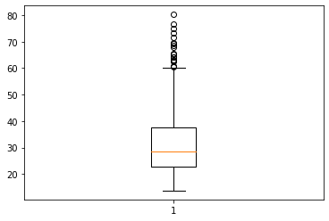

```
Column Name: A3:
```

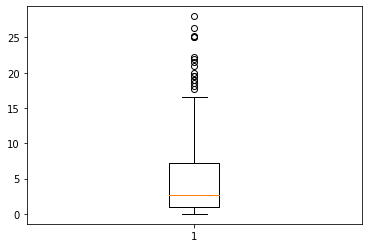

```
Column Name: A8:
```

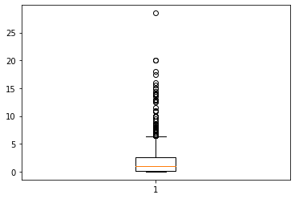

```
Column Name: A11:
```

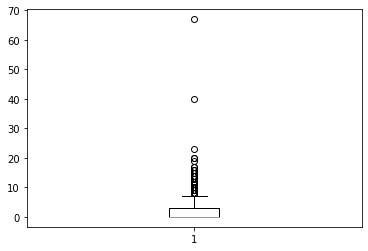

```
Column Name: A14:
```

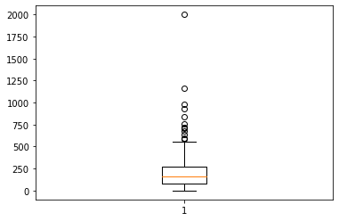

```
Column Name: A15:
```

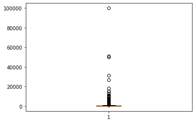

```python
numerical_cols = Data.select_dtypes(include=['float64', 'int64']).columns.tolist()
for col in numerical_cols:
    print(f"Column Name: {col}:")
    plt.boxplot(Data[col])
    plt.show()
```

From the above boxplots, we found that the data are not noramlly distributed for all the features. Range is particularly huge for feature A14 and A15. As this is an anonymised dataset, we have limited domain knowledge, and we have no reason to believe that IQR based outlier detection is applicable. Thus, all the values in the datasets might be perfectly valid and we do not flag any numerical values as outliers regardless of their value.

## 6. Handling Categorical Descriptive features

Generate the summary statistics and list all the value counts for all each categorical features

```python
Data.describe(include=np.object)
```

|  | A1 | A4 | A5 | A6 | A7 | A9 | A10 | A12 | A13 | A16 |
| --- | --- | --- | --- | --- | --- | --- | --- | --- | --- | --- |
| count | 690 | 690 | 690 | 690 | 690 | 690 | 690 | 690 | 690 | 690 |
| unique | 3 | 4 | 4 | 15 | 10 | 2 | 2 | 2 | 3 | 2 |
| top | b | u | g | c | v | t | f | f | g | - |
| freq | 468 | 519 | 519 | 137 | 399 | 361 | 395 | 374 | 625 | 383 |

```python
categorical_cols = Data.columns[Data.dtypes==object].tolist()
for col in categorical_cols:
    print(f'Before Transformation {col} -', Data[col].unique())
    print(Data[col].value_counts())
```

```
Before Transformation A1 - ['b' 'a' '?']
b    468
a    210
?     12
Name: A1, dtype: int64
Before Transformation A4 - ['u' 'y' '?' 'l']
u    519
y    163
?      6
l      2
Name: A4, dtype: int64
Before Transformation A5 - ['g' 'p' '?' 'gg']
g     519
p     163
?       6
gg      2
Name: A5, dtype: int64
Before Transformation A6 - ['w' 'q' 'm' 'r' 'cc' 'k' 'c' 'd' 'x' 'i' 'e' 'aa' 'ff' 'j' '?']
c     137
q      78
w      64
i      59
aa     54
ff     53
k      51
cc     41
m      38
x      38
d      30
e      25
j      10
?       9
r       3
Name: A6, dtype: int64
Before Transformation A7 - ['v' 'h' 'bb' 'ff' 'j' 'z' '?' 'o' 'dd' 'n']
v     399
h     138
bb     59
ff     57
?       9
```

[output cut: 12 more lines]

```
t    295
Name: A10, dtype: int64
Before Transformation A12 - ['f' 't']
f    374
t    316
Name: A12, dtype: int64
Before Transformation A13 - ['g' 's' 'p']
g    625
s     57
p      8
Name: A13, dtype: int64
Before Transformation A16 - ['+' '-']
-    383
+    307
Name: A16, dtype: int64
```

`'?'` is found in some of the categorical features, replace it with the mode value of that feature, check the unique values and their corresponding counts of each feature to verify mode values have been imputed.

```python
categorical_cols = Data.columns[Data.dtypes==object].tolist()
for col in categorical_cols:
    Data.loc[(Data[col]=='?'), col]= stat.mode(Data[col])
    print(f'After Transformation {col} -', Data[col].unique())
    print(Data[col].value_counts())
```

```
After Transformation A1 - ['b' 'a']
b    480
a    210
Name: A1, dtype: int64
After Transformation A4 - ['u' 'y' 'l']
u    525
y    163
l      2
Name: A4, dtype: int64
After Transformation A5 - ['g' 'p' 'gg']
g     525
p     163
gg      2
Name: A5, dtype: int64
After Transformation A6 - ['w' 'q' 'm' 'r' 'cc' 'k' 'c' 'd' 'x' 'i' 'e' 'aa' 'ff' 'j']
c     146
q      78
w      64
i      59
aa     54
ff     53
k      51
cc     41
m      38
x      38
d      30
e      25
j      10
r       3
Name: A6, dtype: int64
After Transformation A7 - ['v' 'h' 'bb' 'ff' 'j' 'z' 'o' 'dd' 'n']
v     408
h     138
bb     59
ff     57
j       8
z       8
dd      6
n       4
o       2
Name: A7, dtype: int64
After Transformation A9 - ['t' 'f']
t    361
f    329
Name: A9, dtype: int64
After Transformation A10 - ['t' 'f']
f    395
t    295
Name: A10, dtype: int64
After Transformation A12 - ['f' 't']
f    374
t    316
Name: A12, dtype: int64
After Transformation A13 - ['g' 's' 'p']
g    625
s     57
p      8
Name: A13, dtype: int64
After Transformation A16 - ['+' '-']
-    383
+    307
Name: A16, dtype: int64
```

From the output of previous step, we could find that column `A4` and `A5` have the same number of unique values, check whether each unique values have a mapping count in the respective column.

```python
Data.groupby(['A4', 'A5']).size()
```

```
A4  A5
l   gg      2
u   g     525
y   p     163
dtype: int64
```

The above output shows that column A4 and A5 might carry the same information as in column A4 whenever there is a value of `l`, A5 would have a value of `gg`, etc. However in the file `Assignment1_Q1_crx.names`, it tells us that A4 could accept 4 inputs and A5 could only take in 3 as below:

```
A4: u, y, l, t.
A5: g, p, gg.
```

even though we should simplify our dataset by removing column(s) with redundant information, but in this case, as we don't have any domain knowledge on this anonymised dataset, we better play safe and keep both columns, just bear in mind about this finding, and we could come back to revise the method of cleaning the dataset once we improve our knowledge on it.

## 7. Discretize the A2 numerical descriptive feature

For the `A2` numerical descriptive feature, discretize it via equal-frequency binning with 3 bins named "low", "medium", and "high", and then handle with integer encoding.

```python
Data['A2'] = pd.qcut(Data['A2'], q=3, labels=['low', 'medium', 'high'])
```

```python
level_mapping = {'low': 0, 'medium': 1, 'high': 2}
Data['A2'] = Data['A2'].replace(level_mapping)
Data['A2'].value_counts()
```

```
1    231
0    230
2    229
Name: A2, dtype: int64
```

## 8. Handling target feature

Remove feature `A16` as it's the class attribute in the dataset. Call it target. The rest of the features will be the descriptive features in our dataset.

```python
target = Data['A16']
Data = Data.drop(columns='A16')

target.value_counts()
```

```
-    383
+    307
Name: A16, dtype: int64
```

Label-encode the target feature so that the positive class is encoded as "1". The negative class should be encoded as "0". Confirm correctness of our label-encoding by getting a value counts.

```python
target = target.replace({'-': 0, '+': 1})

target.value_counts()
```

```
0    383
1    307
Name: A16, dtype: int64
```

## 9. One-hot encoding for categorical features

As all the categorical features appear to be nominal. Perform one-hot encoding for all the descriptive categorical features and call this encoded data frame as `Data_encoded`. If a categorical descriptive feature has only 2 levels, encode it with only one binary variable. For other categorical features (with more than 2 levels), use regular one-hot-encoding (where number of binary variables are equal to the number of distinct levels).

```python
Data_encoded = Data.copy()  # retain original Data without encoding for further analysis
print(Data_encoded.columns)

# if a categorical descriptive feature has only 2 levels,
# define only one binary variable
categorical_cols = Data_encoded.columns[Data.dtypes==object].tolist()
for col in categorical_cols:
    q = len(Data_encoded[col].unique())
    if (q == 2):
        Data_encoded[col] = pd.get_dummies(Data_encoded[col], drop_first=True)

# for other categorical features (with > 2 levels),
# perform regular one-hot-encoding using pd.get_dummies()
# if a feature is numeric, it will be untouched
Data_encoded = pd.get_dummies(Data_encoded)

print(Data_encoded.columns)
```

```
Index(['A1', 'A2', 'A3', 'A4', 'A5', 'A6', 'A7', 'A8', 'A9', 'A10', 'A11',
       'A12', 'A13', 'A14', 'A15'],
      dtype='object')
Index(['A1', 'A2', 'A3', 'A8', 'A9', 'A10', 'A11', 'A12', 'A14', 'A15', 'A4_l',
       'A4_u', 'A4_y', 'A5_g', 'A5_gg', 'A5_p', 'A6_aa', 'A6_c', 'A6_cc',
       'A6_d', 'A6_e', 'A6_ff', 'A6_i', 'A6_j', 'A6_k', 'A6_m', 'A6_q', 'A6_r',
       'A6_w', 'A6_x', 'A7_bb', 'A7_dd', 'A7_ff', 'A7_h', 'A7_j', 'A7_n',
       'A7_o', 'A7_v', 'A7_z', 'A13_g', 'A13_p', 'A13_s'],
      dtype='object')
```

Check the data types of all the descriptive features. Once they are numerical, it's almost ready to be fed into scikit learn module.

```python
Data_encoded.dtypes
```

```
A1         uint8
A2         int64
A3       float64
A8       float64
A9         uint8
A10        uint8
A11        int64
A12        uint8
A14      float64
A15        int64
A4_l       uint8
A4_u       uint8
A4_y       uint8
A5_g       uint8
A5_gg      uint8
A5_p       uint8
A6_aa      uint8
A6_c       uint8
A6_cc      uint8
A6_d       uint8
A6_e       uint8
A6_ff      uint8
A6_i       uint8
A6_j       uint8
A6_k       uint8
A6_m       uint8
A6_q       uint8
A6_r       uint8
A6_w       uint8
A6_x       uint8
A7_bb      uint8
A7_dd      uint8
A7_ff      uint8
A7_h       uint8
A7_j       uint8
A7_n       uint8
A7_o       uint8
A7_v       uint8
A7_z       uint8
A13_g      uint8
A13_p      uint8
A13_s      uint8
dtype: object
```

## 10. Normalization

Perform a range normalization of the descriptive features using standard scaling within the preprocessing submodule of Scikit-Learn, and call it `Data_encoded_norm_numpy`. We shall leave `Data_encoded` around to keep track of column names.

```python
from sklearn import preprocessing

Data_scaler = preprocessing.StandardScaler()

Data_encoded_norm_numpy = Data_scaler.fit_transform(Data_encoded)
```

As the `Data_encoded_norm_numpy` is a NumPy array, all the column names are lost. Define a new Pandas data frame called `Data_encoded_norm_df` from `Data_encoded_norm_numpy` with the column names of `Data_encoded`. Finally, get the shape and a description of `Data_encoded_norm_df` with include='all' option.

```python
Data_encoded_norm_df = pd.DataFrame(Data_encoded_norm_numpy,
                                    columns=Data_encoded.columns)
```

```python
print(f'Shape of Data_encoded_norm_df is {Data_encoded_norm_df.shape}\n')

Data_encoded_norm_df.describe(include='all').round(3)
```

```
Shape of Data_encoded_norm_df is (690, 42)
```

|  | A1 | A2 | A3 | A8 | A9 | A10 | A11 | A12 | A14 | A15 | ... | A7_ff | A7_h | A7_j | A7_n | A7_o | A7_v | A7_z | A13_g | A13_p | A13_s |
| --- | --- | --- | --- | --- | --- | --- | --- | --- | --- | --- | --- | --- | --- | --- | --- | --- | --- | --- | --- | --- | --- |
| count | 690.000 | 690.000 | 690.000 | 690.000 | 690.000 | 690.000 | 690.000 | 690.000 | 690.000 | 690.000 | ... | 690.000 | 690.000 | 690.000 | 690.000 | 690.000 | 690.000 | 690.000 | 690.000 | 690.000 | 690.000 |
| mean | 0.000 | -0.000 | 0.000 | 0.000 | 0.000 | -0.000 | 0.000 | -0.000 | 0.000 | -0.000 | ... | 0.000 | 0.000 | 0.000 | -0.000 | -0.000 | -0.000 | -0.000 | 0.000 | -0.000 | -0.000 |
| std | 1.001 | 1.001 | 1.001 | 1.001 | 1.001 | 1.001 | 1.001 | 1.001 | 1.001 | 1.001 | ... | 1.001 | 1.001 | 1.001 | 1.001 | 1.001 | 1.001 | 1.001 | 1.001 | 1.001 | 1.001 |
| min | -1.512 | -1.224 | -0.957 | -0.665 | -1.048 | -0.864 | -0.494 | -0.919 | -1.067 | -0.195 | ... | -0.300 | -0.500 | -0.108 | -0.076 | -0.054 | -1.203 | -0.108 | -3.101 | -0.108 | -0.300 |
| 25% | -1.512 | -1.224 | -0.756 | -0.616 | -1.048 | -0.864 | -0.494 | -0.919 | -0.602 | -0.195 | ... | -0.300 | -0.500 | -0.108 | -0.076 | -0.054 | -1.203 | -0.108 | 0.322 | -0.108 | -0.300 |
| 50% | 0.661 | 0.002 | -0.404 | -0.366 | 0.955 | -0.864 | -0.494 | -0.919 | -0.137 | -0.194 | ... | -0.300 | -0.500 | -0.108 | -0.076 | -0.054 | 0.831 | -0.108 | 0.322 | -0.108 | -0.300 |
| 75% | 0.661 | 1.228 | 0.492 | 0.120 | 0.955 | 1.157 | 0.123 | 1.088 | 0.514 | -0.119 | ... | -0.300 | -0.500 | -0.108 | -0.076 | -0.054 | 0.831 | -0.108 | 0.322 | -0.108 | -0.300 |
| max | 0.661 | 1.228 | 4.672 | 7.858 | 0.955 | 1.157 | 13.294 | 1.088 | 10.557 | 19.012 | ... | 3.332 | 2.000 | 9.233 | 13.096 | 18.547 | 0.831 | 9.233 | 0.322 | 9.233 | 3.332 |

8 rows × 42 columns

Sanity check some categorical features, there should be only 3 unique values for feature `A2` and 2 unique values for feature `A7_h`.

```python
Data_encoded_norm_df['A2'].value_counts()
```

```
 0.001777    231
-1.224303    230
 1.227857    229
Name: A2, dtype: int64
```

```python
Data_encoded_norm_df['A7_h'].value_counts()
```

```
-0.5    552
 2.0    138
Name: A7_h, dtype: int64
```

Define a new data frame called `df_clean` which is the combination of the normalized and scaled descriptive features and the target feature with the target feature as the last column. Ensure target feature is a numpy array by calling .values.

```python
df_clean = Data_encoded_norm_df.assign(target = target.values)
```

## 11. Summary of the final clean dataset: df_clean

Generate the summary output of the final data frame `df_clean`.

```python
pd.set_option('display.max_columns', 50)
df_clean.shape
```

```
(690, 43)
```

```python
df_clean.describe(include='all').round(3)
```

|  | A1 | A2 | A3 | A8 | A9 | A10 | A11 | A12 | A14 | A15 | A4_l | A4_u | A4_y | A5_g | A5_gg | A5_p | A6_aa | A6_c | A6_cc | A6_d | A6_e | A6_ff | A6_i | A6_j | A6_k | A6_m | A6_q | A6_r | A6_w | … |
| --- | --- | --- | --- | --- | --- | --- | --- | --- | --- | --- | --- | --- | --- | --- | --- | --- | --- | --- | --- | --- | --- | --- | --- | --- | --- | --- | --- | --- | --- | --- |
| count | 690.000 | 690.000 | 690.000 | 690.000 | 690.000 | 690.000 | 690.000 | 690.000 | 690.000 | 690.000 | 690.000 | 690.000 | 690.000 | 690.000 | 690.000 | 690.000 | 690.000 | 690.000 | 690.000 | 690.000 | 690.000 | 690.000 | 690.000 | 690.000 | 690.000 | 690.000 | 690.000 | 690.000 | 690.000 | … |
| mean | 0.000 | -0.000 | 0.000 | 0.000 | 0.000 | -0.000 | 0.000 | -0.000 | 0.000 | -0.000 | -0.000 | 0.000 | 0.000 | 0.000 | -0.000 | 0.000 | 0.000 | 0.000 | -0.000 | 0.000 | 0.000 | 0.000 | -0.000 | 0.000 | 0.000 | 0.000 | 0.000 | -0.000 | -0.000 | … |
| std | 1.001 | 1.001 | 1.001 | 1.001 | 1.001 | 1.001 | 1.001 | 1.001 | 1.001 | 1.001 | 1.001 | 1.001 | 1.001 | 1.001 | 1.001 | 1.001 | 1.001 | 1.001 | 1.001 | 1.001 | 1.001 | 1.001 | 1.001 | 1.001 | 1.001 | 1.001 | 1.001 | 1.001 | 1.001 | … |
| min | -1.512 | -1.224 | -0.957 | -0.665 | -1.048 | -0.864 | -0.494 | -0.919 | -1.067 | -0.195 | -0.054 | -1.784 | -0.556 | -1.784 | -0.054 | -0.556 | -0.291 | -0.518 | -0.251 | -0.213 | -0.194 | -0.288 | -0.306 | -0.121 | -0.283 | -0.241 | -0.357 | -0.066 | -0.320 | … |
| 25% | -1.512 | -1.224 | -0.756 | -0.616 | -1.048 | -0.864 | -0.494 | -0.919 | -0.602 | -0.195 | -0.054 | 0.561 | -0.556 | 0.561 | -0.054 | -0.556 | -0.291 | -0.518 | -0.251 | -0.213 | -0.194 | -0.288 | -0.306 | -0.121 | -0.283 | -0.241 | -0.357 | -0.066 | -0.320 | … |
| 50% | 0.661 | 0.002 | -0.404 | -0.366 | 0.955 | -0.864 | -0.494 | -0.919 | -0.137 | -0.194 | -0.054 | 0.561 | -0.556 | 0.561 | -0.054 | -0.556 | -0.291 | -0.518 | -0.251 | -0.213 | -0.194 | -0.288 | -0.306 | -0.121 | -0.283 | -0.241 | -0.357 | -0.066 | -0.320 | … |
| 75% | 0.661 | 1.228 | 0.492 | 0.120 | 0.955 | 1.157 | 0.123 | 1.088 | 0.514 | -0.119 | -0.054 | 0.561 | -0.556 | 0.561 | -0.054 | -0.556 | -0.291 | -0.518 | -0.251 | -0.213 | -0.194 | -0.288 | -0.306 | -0.121 | -0.283 | -0.241 | -0.357 | -0.066 | -0.320 | … |
| max | 0.661 | 1.228 | 4.672 | 7.858 | 0.955 | 1.157 | 13.294 | 1.088 | 10.557 | 19.012 | 18.547 | 0.561 | 1.798 | 0.561 | 18.547 | 1.798 | 3.432 | 1.930 | 3.979 | 4.690 | 5.158 | 3.467 | 3.270 | 8.246 | 3.540 | 4.142 | 2.801 | 15.133 | 3.127 | … |

```python
df_clean.head(5)
```

|  | A1 | A2 | A3 | A8 | A9 | A10 | A11 | A12 | A14 | A15 | A4_l | A4_u | A4_y | A5_g | A5_gg | A5_p | A6_aa | A6_c | A6_cc | A6_d | A6_e | A6_ff | A6_i | A6_j | A6_k | A6_m | A6_q | A6_r | A6_w | … |
| --- | --- | --- | --- | --- | --- | --- | --- | --- | --- | --- | --- | --- | --- | --- | --- | --- | --- | --- | --- | --- | --- | --- | --- | --- | --- | --- | --- | --- | --- | --- |
| 0 | 0.661438 | 0.001777 | -0.956613 | -0.291083 | 0.95465 | 1.157144 | -0.288101 | -0.919195 | 0.107155 | -0.195413 | -0.053916 | 0.560612 | -0.556146 | 0.560612 | -0.053916 | -0.556146 | -0.291386 | -0.518056 | -0.251345 | -0.213201 | -0.193892 | -0.288448 | -0.305782 | -0.121268 | -0.282511 | -0.241417 | -0.357003 | -0.066082 | 3.127499 | … |
| 1 | -1.511858 | 1.227857 | -0.060051 | 0.244190 | 0.95465 | 1.157144 | 0.740830 | -0.919195 | -0.816912 | -0.087852 | -0.053916 | 0.560612 | -0.556146 | 0.560612 | -0.053916 | -0.556146 | -0.291386 | -0.518056 | -0.251345 | -0.213201 | -0.193892 | -0.288448 | -0.305782 | -0.121268 | -0.282511 | -0.241417 | 2.801099 | -0.066082 | -0.319744 | … |
| 2 | -1.511858 | 0.001777 | -0.856102 | -0.216324 | 0.95465 | -0.864196 | -0.493887 | -0.919195 | 0.560471 | -0.037144 | -0.053916 | 0.560612 | -0.556146 | 0.560612 | -0.053916 | -0.556146 | -0.291386 | -0.518056 | -0.251345 | -0.213201 | -0.193892 | -0.288448 | -0.305782 | -0.121268 | -0.282511 | -0.241417 | 2.801099 | -0.066082 | -0.319744 | … |
| 3 | 0.661438 | 0.001777 | -0.647038 | 0.456505 | 0.95465 | 1.157144 | 0.535044 | 1.087908 | -0.485643 | -0.194837 | -0.053916 | 0.560612 | -0.556146 | 0.560612 | -0.053916 | -0.556146 | -0.291386 | -0.518056 | -0.251345 | -0.213201 | -0.193892 | -0.288448 | -0.305782 | -0.121268 | -0.282511 | -0.241417 | -0.357003 | -0.066082 | 3.127499 | … |
| 4 | 0.661438 | -1.224303 | 0.174141 | -0.153526 | 0.95465 | -0.864196 | -0.493887 | -0.919195 | -0.369408 | -0.195413 | -0.053916 | 0.560612 | -0.556146 | 0.560612 | -0.053916 | -0.556146 | -0.291386 | -0.518056 | -0.251345 | -0.213201 | -0.193892 | -0.288448 | -0.305782 | -0.121268 | -0.282511 | -0.241417 | -0.357003 | -0.066082 | 3.127499 | … |

Write the final dataset `df_clean` to a CSV file called `df_clean.csv`.

```python
# set index to False so that row IDs are not written
df_clean.to_csv('df_clean.csv', index=False)
```

# Question 2 - KNN

Use KNN algorithm with Manhattan distance, predict the level of corruption in `Russia` based on a range of macro-economic and social features of a list of given countries. CPI index measures the perceived levels of corruption in the public sector of countries and ranges from 0 (highly corrupt) to 10 (very clean).

## 1. Read in the given data file

Read `Asignment1_Q2.csv` file into a dataframe `oCorr`, whcih stands for "original Corruption".

```python
oCorr = pd.read_csv("Asignment1_Q2.csv", index_col=False, header=0)
oCorr
```

|  | COUNTRY_ID | LIFE_EXP | TOP10_INCOME | INFANT_MORT | MIL_SPEND | SCHOOL_YEARS | CPI |
| --- | --- | --- | --- | --- | --- | --- | --- |
| 0 | Afghanistan | 59.61 | 23.21 | 74.3 | 4.44 | 0.4 | 1.5171 |
| 1 | Haiti | 45.00 | 47.67 | 73.1 | 0.09 | 3.4 | 1.7999 |
| 2 | Nigeria | 51.30 | 38.23 | 82.6 | 1.07 | 4.1 | 2.4493 |
| 3 | Egypt | 70.48 | 26.58 | 19.6 | 1.86 | 5.3 | 2.8622 |
| 4 | Argentina | 75.77 | 32.30 | 13.3 | 0.76 | 10.1 | 2.9961 |
| 5 | China | 74.87 | 29.98 | 13.7 | 1.95 | 6.4 | 3.6356 |
| 6 | Brazil | 73.12 | 42.93 | 14.5 | 1.43 | 7.2 | 3.7741 |
| 7 | Israel | 81.30 | 28.80 | 3.6 | 6.77 | 12.5 | 5.8069 |
| 8 | U.S.A | 78.51 | 29.85 | 6.3 | 4.72 | 13.7 | 7.1357 |
| 9 | Ireland | 80.15 | 27.23 | 3.5 | 0.60 | 11.5 | 7.536 |
| 10 | U.K. | 80.09 | 28.49 | 4.4 | 2.59 | 13.0 | 7.7751 |
| 11 | Germany | 80.24 | 22.07 | 3.5 | 1.31 | 12.0 | 8.0461 |
| 12 | Canada | 80.99 | 24.79 | 4.9 | 1.42 | 14.2 | 8.6725 |
| 13 | Australia | 82.09 | 25.40 | 4.2 | 1.86 | 11.5 | 8.8442 |
| 14 | Sweden | 81.43 | 22.18 | 2.4 | 1.27 | 12.8 | 9.2985 |
| 15 | New Zealand | 80.67 | 27.81 | 4.9 | 1.13 | 12.3 | 9.4627 |
| 16 | Russia | 67.62 | 31.68 | 10.0 | 3.87 | 12.9 | ? |

## 2. Check the datatypes

```python
oCorr.dtypes
```

```
COUNTRY_ID       object
LIFE_EXP        float64
TOP10_INCOME    float64
INFANT_MORT     float64
MIL_SPEND       float64
SCHOOL_YEARS    float64
CPI              object
dtype: object
```

## 3. Data validation and preparation

Since CPI should be a numeric value, convert it to numeric.

```python
oCorr['CPI']=oCorr['CPI'].apply(pd.to_numeric, errors='coerce')
```

Last row in the dataset is our query row which we want to predict the CPI index. Extract the last row into a new dataframe, `q` and remove it from the dataset, `oCorr`. `oCorr` is now our training data set. Please note, information for Afghanistan can be located with index 0, etc.

```python
q = oCorr.iloc[-1,:].to_frame()
q=q.T.reset_index(drop=True)
```

```python
q
```

|  | COUNTRY_ID | LIFE_EXP | TOP10_INCOME | INFANT_MORT | MIL_SPEND | SCHOOL_YEARS | CPI |
| --- | --- | --- | --- | --- | --- | --- | --- |
| 0 | Russia | 67.62 | 31.68 | 10 | 3.87 | 12.9 | NaN |

```python
oCorr = oCorr.iloc[:-1,:]
```

```python
oCorr
```

|  | COUNTRY_ID | LIFE_EXP | TOP10_INCOME | INFANT_MORT | MIL_SPEND | SCHOOL_YEARS | CPI |
| --- | --- | --- | --- | --- | --- | --- | --- |
| 0 | Afghanistan | 59.61 | 23.21 | 74.3 | 4.44 | 0.4 | 1.5171 |
| 1 | Haiti | 45.00 | 47.67 | 73.1 | 0.09 | 3.4 | 1.7999 |
| 2 | Nigeria | 51.30 | 38.23 | 82.6 | 1.07 | 4.1 | 2.4493 |
| 3 | Egypt | 70.48 | 26.58 | 19.6 | 1.86 | 5.3 | 2.8622 |
| 4 | Argentina | 75.77 | 32.30 | 13.3 | 0.76 | 10.1 | 2.9961 |
| 5 | China | 74.87 | 29.98 | 13.7 | 1.95 | 6.4 | 3.6356 |
| 6 | Brazil | 73.12 | 42.93 | 14.5 | 1.43 | 7.2 | 3.7741 |
| 7 | Israel | 81.30 | 28.80 | 3.6 | 6.77 | 12.5 | 5.8069 |
| 8 | U.S.A | 78.51 | 29.85 | 6.3 | 4.72 | 13.7 | 7.1357 |
| 9 | Ireland | 80.15 | 27.23 | 3.5 | 0.60 | 11.5 | 7.5360 |
| 10 | U.K. | 80.09 | 28.49 | 4.4 | 2.59 | 13.0 | 7.7751 |
| 11 | Germany | 80.24 | 22.07 | 3.5 | 1.31 | 12.0 | 8.0461 |
| 12 | Canada | 80.99 | 24.79 | 4.9 | 1.42 | 14.2 | 8.6725 |
| 13 | Australia | 82.09 | 25.40 | 4.2 | 1.86 | 11.5 | 8.8442 |
| 14 | Sweden | 81.43 | 22.18 | 2.4 | 1.27 | 12.8 | 9.2985 |
| 15 | New Zealand | 80.67 | 27.81 | 4.9 | 1.13 | 12.3 | 9.4627 |

As CPI is our target feature, extract that into a separate dataframe, `oTarget`. Drop this feature in the `oCorr` and `q` dataframe.

```python
oTarget = oCorr['CPI']
oCorr = oCorr.drop(columns='CPI')
q = q.drop(columns='CPI')
```

```python
OCorrMatrix = oCorr.iloc[:, 1:].values
qMatrix = q.iloc[:, 1:].values
```

Transform the training and query dataframe into 2-Dimensional numpy arrays for lateral calculation.

```python
type(OCorrMatrix)
```

```
numpy.ndarray
```

```python
OCorrMatrix
```

```
array([[59.61, 23.21, 74.3 ,  4.44,  0.4 ],
       [45.  , 47.67, 73.1 ,  0.09,  3.4 ],
       [51.3 , 38.23, 82.6 ,  1.07,  4.1 ],
       [70.48, 26.58, 19.6 ,  1.86,  5.3 ],
       [75.77, 32.3 , 13.3 ,  0.76, 10.1 ],
       [74.87, 29.98, 13.7 ,  1.95,  6.4 ],
       [73.12, 42.93, 14.5 ,  1.43,  7.2 ],
       [81.3 , 28.8 ,  3.6 ,  6.77, 12.5 ],
       [78.51, 29.85,  6.3 ,  4.72, 13.7 ],
       [80.15, 27.23,  3.5 ,  0.6 , 11.5 ],
       [80.09, 28.49,  4.4 ,  2.59, 13.  ],
       [80.24, 22.07,  3.5 ,  1.31, 12.  ],
       [80.99, 24.79,  4.9 ,  1.42, 14.2 ],
       [82.09, 25.4 ,  4.2 ,  1.86, 11.5 ],
       [81.43, 22.18,  2.4 ,  1.27, 12.8 ],
       [80.67, 27.81,  4.9 ,  1.13, 12.3 ]])
```

```python
qMatrix
```

```
array([[67.62, 31.68, 10.0, 3.87, 12.9]], dtype=object)
```

## 4. Part A

### Question

What value would a 3-nearest neighbor prediction model using Manhattan distance return for the CPI of Russia?

Define a function, `calManhattan`, which would calculate the Manhattan distance of each row in the descriptive Matrix to the target Matrix. There is only one row in the target matrix with index 0. The calculated distance would be returned as a 1-Dimensional numpy array.

```python
def calManhattan(descMatrix, targetMatrix):
    M_dist=np.zeros(len(descMatrix))
    for i in range(len(descMatrix)):
        M_dist[i]= sum(np.abs(descMatrix[i,:] - targetMatrix[0,:]))
    return M_dist
```

Pass in the training and query matrix to the `calManhattan` function to obtain the manhattan distance of each row, store the result in the numpy array, `M`. Please note, first Cell with index=0, is the manhattan distance between Afghanistan and RuAssia, etc.

```python
M = calManhattan(OCorrMatrix, qMatrix)
M
```

```
array([ 93.85, 114.99, 107.07,  27.17,  17.98,  21.07,  29.39,  26.26,
        18.07,  28.15,  22.64,  32.19,  29.11,  29.96,  33.61,  25.36])
```

Construct a dataframe, `result_a`, which shows the manhattan distance for each country and it's corresponding target feature.

```python
data_a = { 'COUNTRY_ID':oCorr['COUNTRY_ID'].tolist() , 'Manhattan distance to Russia': M.tolist(), 'CPI' : oTarget.tolist()}
result_a = pd.DataFrame(data_a)
```

Sort `result_a` base on the manhattan distance in ascending order

```python
result_a = result_a.sort_values('Manhattan distance to Russia')
result_a
```

|  | COUNTRY_ID | Manhattan distance to Russia | CPI |
| --- | --- | --- | --- |
| 4 | Argentina | 17.98 | 2.9961 |
| 8 | U.S.A | 18.07 | 7.1357 |
| 5 | China | 21.07 | 3.6356 |
| 10 | U.K. | 22.64 | 7.7751 |
| 15 | New Zealand | 25.36 | 9.4627 |
| 7 | Israel | 26.26 | 5.8069 |
| 3 | Egypt | 27.17 | 2.8622 |
| 9 | Ireland | 28.15 | 7.5360 |
| 12 | Canada | 29.11 | 8.6725 |
| 6 | Brazil | 29.39 | 3.7741 |
| 13 | Australia | 29.96 | 8.8442 |
| 11 | Germany | 32.19 | 8.0461 |
| 14 | Sweden | 33.61 | 9.2985 |
| 0 | Afghanistan | 93.85 | 1.5171 |
| 2 | Nigeria | 107.07 | 2.4493 |
| 1 | Haiti | 114.99 | 1.7999 |

Draw the conclusion from `result_a` as below:

### **Answer**

The nearest 3 neighbors to Russia are Argentina, USA and China. The CPI value will be returned by the model is the average CPI score for these 3 neighbors, which is

```python
nearest3CPI = result_a.iloc[0:3,2].tolist()
print('CPI for the first 3 neighbors:', nearest3CPI)
```

```
CPI for the first 3 neighbors: [2.9961, 7.1357, 3.6356]
```

```python
avgnearest3CPI = np.round((sum(nearest3CPI)/3), 4)
print('Average CPI for the first 3 neighbors:', avgnearest3CPI)
```

```
Average CPI for the first 3 neighbors: 4.5891
```

## 5. Part B

### Question

What value would a weighted k-NN prediction model return for the CPI of Russia? Use k =16 (i.e., the full dataset) and a weighting scheme of the reciprocal of the squared Manhattan distance between the neighbor and the query.

Calculating the Weight matrix, `W`, which is the reciprocal of the squared Manhattan distance between Each neighbor country and the query `Russia`

```python
W = 1 / (M)**2
```

```python
W
```

```
array([1.13535440e-04, 7.56275188e-05, 8.72297032e-05, 1.35463011e-03,
       3.09328991e-03, 2.25253179e-03, 1.15771278e-03, 1.45014208e-03,
       3.06255358e-03, 1.26195306e-03, 1.95095456e-03, 9.65068292e-04,
       1.18009125e-03, 1.11408001e-03, 8.85243966e-04, 1.55489656e-03])
```

Calculating the weights multiplied by the instance target value (i.e. CPI) and store that as our `product` matrix

```python
product = W*oTarget.values
```

Construct a dataframe, `result_b`, which shows the manhattan distance for each country and it's corresponding target feature (i.e. CPI), weight and wight x CPI.

```python
data_b = { 'COUNTRY_ID':oCorr['COUNTRY_ID'].tolist() , 'Manhattan distance to Russia': M.tolist(), 'CPI' : oTarget.tolist(), 'Weight' : W.tolist(), 'Weight x CPI': product.tolist()}
result_b = pd.DataFrame(data_b)
```

Sort `result_b` base on the manhattan distance in ascending order

```python
result_b = result_b.sort_values('Manhattan distance to Russia')
result_b
```

|  | COUNTRY_ID | Manhattan distance to Russia | CPI | Weight | Weight x CPI |
| --- | --- | --- | --- | --- | --- |
| 4 | Argentina | 17.98 | 2.9961 | 0.003093 | 0.009268 |
| 8 | U.S.A | 18.07 | 7.1357 | 0.003063 | 0.021853 |
| 5 | China | 21.07 | 3.6356 | 0.002253 | 0.008189 |
| 10 | U.K. | 22.64 | 7.7751 | 0.001951 | 0.015169 |
| 15 | New Zealand | 25.36 | 9.4627 | 0.001555 | 0.014714 |
| 7 | Israel | 26.26 | 5.8069 | 0.001450 | 0.008421 |
| 3 | Egypt | 27.17 | 2.8622 | 0.001355 | 0.003877 |
| 9 | Ireland | 28.15 | 7.5360 | 0.001262 | 0.009510 |
| 12 | Canada | 29.11 | 8.6725 | 0.001180 | 0.010234 |
| 6 | Brazil | 29.39 | 3.7741 | 0.001158 | 0.004369 |
| 13 | Australia | 29.96 | 8.8442 | 0.001114 | 0.009853 |
| 11 | Germany | 32.19 | 8.0461 | 0.000965 | 0.007765 |
| 14 | Sweden | 33.61 | 9.2985 | 0.000885 | 0.008231 |
| 0 | Afghanistan | 93.85 | 1.5171 | 0.000114 | 0.000172 |
| 2 | Nigeria | 107.07 | 2.4493 | 0.000087 | 0.000214 |
| 1 | Haiti | 114.99 | 1.7999 | 0.000076 | 0.000136 |

### **Answer**

Draw the conclusion from `result_b` as below:

Since we are using k=16, the value returned by the model is the sum of the instance weights multiplied by the instance target value divided by the sum of the instance weights for all levels:

```python
weight16 = np.round(sum(result_b['Weight x CPI']) / sum(result_b['Weight']),4)
print('Weight CPI using full set of data k = 16:', weight16)
```

```
Weight CPI using full set of data k = 16: 6.1215
```

## 6. Part C

### Question

The descriptive features in this dataset are of different types. For example, some are percentages, others are measured in years, and others are measured in counts per 1,000. We should always consider normalizing our data, but it is particularly important to do this when the descriptive are measured in different units. What value would a 3-nearest neighbor prediction model using Manhattan distance return for the CPI of Russia when the descriptive features have been normalized using range normalization?

Define a function, `normal2DByRow`, which takes a 2-Dimensional `descMatrix` as parameter, and return this matrix after min-max normalization.

```python
def normal2DByRow(descMatrix):
    norm=np.zeros((len(descMatrix), descMatrix.shape[1]))
#    print(len(descMatrix),descMatrix.shape[1])
#    print(norm)
    for i in range(descMatrix.shape[1]):
        minVal= min(descMatrix[:,i])
        maxVal= max(descMatrix[:,i])
        for j in range(len(descMatrix)):
#            print(minVal, maxVal, descMatrix[j,i])
            norm[j,i] = (descMatrix[j,i] - minVal )/ (maxVal - minVal)
#        print(norm)
    return norm
```

Pass in the training matrix `OCorrMatrix` to the `normal2DByRow` function to obtain `nCorrMatrix`.

```python
nCorrMatrix=normal2DByRow(OCorrMatrix)
```

```python
nCorrMatrix
```

```
array([[0.39390671, 0.04453125, 0.89650873, 0.6511976 , 0.        ],
       [0.        , 1.        , 0.88154613, 0.        , 0.2173913 ],
       [0.1698571 , 0.63125   , 1.        , 0.14670659, 0.26811594],
       [0.68697762, 0.17617187, 0.21446384, 0.26497006, 0.35507246],
       [0.82960367, 0.39960937, 0.13591022, 0.1002994 , 0.70289855],
       [0.80533837, 0.30898437, 0.14089776, 0.27844311, 0.43478261],
       [0.75815584, 0.81484375, 0.15087282, 0.2005988 , 0.49275362],
       [0.97870046, 0.26289062, 0.01496259, 1.        , 0.87681159],
       [0.90347803, 0.30390625, 0.04862843, 0.69311377, 0.96376812],
       [0.9476948 , 0.2015625 , 0.01371571, 0.07634731, 0.80434783],
       [0.94607711, 0.25078125, 0.02493766, 0.3742515 , 0.91304348],
       [0.95012133, 0.        , 0.01371571, 0.18263473, 0.84057971],
       [0.97034241, 0.10625   , 0.03117207, 0.1991018 , 1.        ],
       [1.        , 0.13007812, 0.02244389, 0.26497006, 0.80434783],
       [0.98220545, 0.00429687, 0.        , 0.17664671, 0.89855072],
       [0.96171475, 0.22421875, 0.03117207, 0.15568862, 0.86231884]])
```

Define a function, `normalTFromDByRow`, which takes two 2-dimensional `descMatrix` and `targetMatrix` as parameter, `descMatrix` can have any columns and rows, while `targetMatrix` can only have 1 row and same number of columns as descMatrix. We then normalise `targetMatrix` base on the minimum and maximum values of `descMatrix` by Row. This function will return the normalized `targetMatrix`.

```python
def normalTFromDByRow(descMatrix, targetMatrix):
    norm=np.zeros((1, targetMatrix.shape[1]))
#    print(len(descMatrix),descMatrix.shape[1])
#    print(norm)
    for i in range(descMatrix.shape[1]):
        minVal= min(descMatrix[:,i])
        maxVal= max(descMatrix[:,i])
        norm[0,i] = (targetMatrix[0,i]- minVal )/ (maxVal - minVal)
    return norm
```

Pass in the training `OCorrMatrix` and query matrix `qMatrix` to the `normalTFromDByRow` function to obtain `nQMatrix`.

```python
nQMatrix = normalTFromDByRow(OCorrMatrix,qMatrix)
```

```python
nQMatrix
```

```
array([[0.60986789, 0.37539062, 0.09476309, 0.56586826, 0.9057971 ]])
```

Construct a dataframe `nCorrdf` to show the normalized descriptive features with headings.

```python
nCorrDf = pd.DataFrame(data=nCorrMatrix, columns=oCorr.columns[1:])
nCorrDf = pd.concat([oCorr['COUNTRY_ID'].to_frame(), nCorrDf], axis=1)
nCorrDf
```

|  | COUNTRY_ID | LIFE_EXP | TOP10_INCOME | INFANT_MORT | MIL_SPEND | SCHOOL_YEARS |
| --- | --- | --- | --- | --- | --- | --- |
| 0 | Afghanistan | 0.393907 | 0.044531 | 0.896509 | 0.651198 | 0.000000 |
| 1 | Haiti | 0.000000 | 1.000000 | 0.881546 | 0.000000 | 0.217391 |
| 2 | Nigeria | 0.169857 | 0.631250 | 1.000000 | 0.146707 | 0.268116 |
| 3 | Egypt | 0.686978 | 0.176172 | 0.214464 | 0.264970 | 0.355072 |
| 4 | Argentina | 0.829604 | 0.399609 | 0.135910 | 0.100299 | 0.702899 |
| 5 | China | 0.805338 | 0.308984 | 0.140898 | 0.278443 | 0.434783 |
| 6 | Brazil | 0.758156 | 0.814844 | 0.150873 | 0.200599 | 0.492754 |
| 7 | Israel | 0.978700 | 0.262891 | 0.014963 | 1.000000 | 0.876812 |
| 8 | U.S.A | 0.903478 | 0.303906 | 0.048628 | 0.693114 | 0.963768 |
| 9 | Ireland | 0.947695 | 0.201563 | 0.013716 | 0.076347 | 0.804348 |
| 10 | U.K. | 0.946077 | 0.250781 | 0.024938 | 0.374251 | 0.913043 |
| 11 | Germany | 0.950121 | 0.000000 | 0.013716 | 0.182635 | 0.840580 |
| 12 | Canada | 0.970342 | 0.106250 | 0.031172 | 0.199102 | 1.000000 |
| 13 | Australia | 1.000000 | 0.130078 | 0.022444 | 0.264970 | 0.804348 |
| 14 | Sweden | 0.982205 | 0.004297 | 0.000000 | 0.176647 | 0.898551 |
| 15 | New Zealand | 0.961715 | 0.224219 | 0.031172 | 0.155689 | 0.862319 |

Construct a dataframe `nQdf` to show the normalized query with headings.

```python
nQdf = pd.DataFrame(data=nQMatrix, columns=q.columns[1:])
qCountry = q['COUNTRY_ID'].reset_index(drop=True).to_frame()
nQdf = pd.concat([qCountry, nQdf], axis=1)
nQdf
```

|  | COUNTRY_ID | LIFE_EXP | TOP10_INCOME | INFANT_MORT | MIL_SPEND | SCHOOL_YEARS |
| --- | --- | --- | --- | --- | --- | --- |
| 0 | Russia | 0.609868 | 0.375391 | 0.094763 | 0.565868 | 0.905797 |

Pass in the normalised training (`nCorrMatrix`) and query matrix (`nQMatrix`) to the `calManhattan` function to obtain the manhattan distance of each row, store the result in the numpy array, `nM`. Please note, first Cell with index=0, is the Manhattan distance between Afghanistan and Russia, etc.

```python
nM = calManhattan(nCorrMatrix, nQMatrix)
```

```python
nM
```

```
array([2.33969263, 3.27553437, 2.6579499 , 1.24765207, 0.95356907,
       1.06645103, 1.42216374, 1.02425031, 0.5964457 , 1.18367265,
       0.72950718, 1.24514237, 1.15417553, 1.11011129, 1.23466233,
       1.02026766])
```

Construct a dataframe, `result_c`, which shows the manhattan distance after normalization for each country and it's corresponding target feature. Please note, target feature is not normalized.

```python
data_c = { 'COUNTRY_ID':oCorr['COUNTRY_ID'].tolist() , 'Manhattan distance to Russia': nM.tolist(), 'CPI' : oTarget.tolist()}
result_c = pd.DataFrame(data_c)
```

```python
result_c = result_c.sort_values('Manhattan distance to Russia')
result_c
```

|  | COUNTRY_ID | Manhattan distance to Russia | CPI |
| --- | --- | --- | --- |
| 8 | U.S.A | 0.596446 | 7.1357 |
| 10 | U.K. | 0.729507 | 7.7751 |
| 4 | Argentina | 0.953569 | 2.9961 |
| 15 | New Zealand | 1.020268 | 9.4627 |
| 7 | Israel | 1.024250 | 5.8069 |
| 5 | China | 1.066451 | 3.6356 |
| 13 | Australia | 1.110111 | 8.8442 |
| 12 | Canada | 1.154176 | 8.6725 |
| 9 | Ireland | 1.183673 | 7.5360 |
| 14 | Sweden | 1.234662 | 9.2985 |
| 11 | Germany | 1.245142 | 8.0461 |
| 3 | Egypt | 1.247652 | 2.8622 |
| 6 | Brazil | 1.422164 | 3.7741 |
| 0 | Afghanistan | 2.339693 | 1.5171 |
| 2 | Nigeria | 2.657950 | 2.4493 |
| 1 | Haiti | 3.275534 | 1.7999 |

### **Answer**

Draw the conclusion from `result_c` as below:

The nearest 3 neighbors to Russia are USA, UK and Argentina. The CPI value that will be returned by the model is the average CPI score for these 3 neighbors, which is

```python
nearest3CPINorm = result_c.iloc[0:3,2].tolist()
print('CPI for the first 3 neighbors:', nearest3CPINorm)

avgnearest3CPINorm = np.round((sum(nearest3CPINorm)/3), 4)
print('Average CPI for the first 3 neighbors:', avgnearest3CPINorm)
```

```
CPI for the first 3 neighbors: [7.1357, 7.7751, 2.9961]
Average CPI for the first 3 neighbors: 5.969
```

## 7. Part D

### Question

What value would a weighted k-NN prediction model—with k=16 (i.e., the full dataset) and using a weighting scheme of the reciprocal of the squared Manhattan distance between the neighbor and the query return for the CPI of Russia when it is applied to the range-normalized data?

Calculating the Weight matrix, `nW`, which is the reciprocal of the squared Manhattan distance between each neighbor country and the query `Russia` after normalization.

```python
nW = 1 / (nM)**2
```

```python
nW
```

```
array([0.18267638, 0.09320424, 0.14154887, 0.64241107, 1.09975434,
       0.87926171, 0.49442543, 0.95320824, 2.81098273, 0.71373464,
       1.87906094, 0.64500336, 0.75068247, 0.81145971, 0.65599964,
       0.96066454])
```

Calculating the weights multiplied by the instance target value (i.e. CPI) and store that as our `nProduct` matrix

```python
nProduct =nW*oTarget.values
nProduct
```

```
array([ 0.27713833,  0.16775832,  0.34669566,  1.83870896,  3.29497399,
        3.19664388,  1.86601101,  5.53518496, 20.05832945,  5.37870426,
       14.60988668,  5.18976154,  6.51029368,  7.17671193,  6.09981267,
        9.09048034])
```

Construct a dataframe, `result_d`, which shows the manhattan distance for each country and it's corresponding target feature (i.e. CPI), weight and wight x CPI after normalization. Please note, target feature is not normalized.

```python
data_d = { 'COUNTRY_ID':oCorr['COUNTRY_ID'].tolist() , 'Manhattan distance to Russia': nM.tolist(), 'CPI' : oTarget.tolist(), 'Weight' : nW.tolist(), 'Weight x CPI': nProduct.tolist()}
result_d = pd.DataFrame(data_d)
```

```python
result_d = pd.DataFrame(data_d)
```

Sort `result_d` base on the manhattan distance in ascending order

```python
result_d = result_d.sort_values('Manhattan distance to Russia')
result_d
```

|  | COUNTRY_ID | Manhattan distance to Russia | CPI | Weight | Weight x CPI |
| --- | --- | --- | --- | --- | --- |
| 8 | U.S.A | 0.596446 | 7.1357 | 2.810983 | 20.058329 |
| 10 | U.K. | 0.729507 | 7.7751 | 1.879061 | 14.609887 |
| 4 | Argentina | 0.953569 | 2.9961 | 1.099754 | 3.294974 |
| 15 | New Zealand | 1.020268 | 9.4627 | 0.960665 | 9.090480 |
| 7 | Israel | 1.024250 | 5.8069 | 0.953208 | 5.535185 |
| 5 | China | 1.066451 | 3.6356 | 0.879262 | 3.196644 |
| 13 | Australia | 1.110111 | 8.8442 | 0.811460 | 7.176712 |
| 12 | Canada | 1.154176 | 8.6725 | 0.750682 | 6.510294 |
| 9 | Ireland | 1.183673 | 7.5360 | 0.713735 | 5.378704 |
| 14 | Sweden | 1.234662 | 9.2985 | 0.656000 | 6.099813 |
| 11 | Germany | 1.245142 | 8.0461 | 0.645003 | 5.189762 |
| 3 | Egypt | 1.247652 | 2.8622 | 0.642411 | 1.838709 |
| 6 | Brazil | 1.422164 | 3.7741 | 0.494425 | 1.866011 |
| 0 | Afghanistan | 2.339693 | 1.5171 | 0.182676 | 0.277138 |
| 2 | Nigeria | 2.657950 | 2.4493 | 0.141549 | 0.346696 |
| 1 | Haiti | 3.275534 | 1.7999 | 0.093204 | 0.167758 |

### **Answer**

Draw the conclusion from `result_d` as below:

Since we are using k=16, the value returned by the model is the sum of the instance weights multiplied by the instance target value divided by the sum of the instance weights for all levels:

```python
weightNorm16 = np.round(sum(result_d['Weight x CPI']) / sum(result_d['Weight']),4)
print('Weight CPI using full set of data k = 16:', weightNorm16)
```

[output not shown]

## 8. Part E

### Question

The actual 2011 CPI for Russia was 2.4488. Which of the predictions made was the most accurate? Why do you think this was?

### **Answer**

The closest prediction was using 3-nearest neighbor prediction based on the original data. As the data ranges in the dataset are so different, normalization would actually find the non-biased distance (ranking of the instances would not be dominated by the feature with larger values) between the training instances and the query, and then would drive us to calculate the most sensible CPI. If we further examine the data according to the ranking of Manhattan distance and the CPI, we can find that the distance ranking of Russia to the original data set is a bit better than the normalized dataset with CPI close to 2.4488 when k = 3, but overall, we can observe there is no relationship between distance ranking to the CPI index in both datasets for this particular instance. ( Results in part b and d clearly explain so when we wanna find the CPI index with the full dataset.) Normalizing data and multiply the weight with CPI, will only amplify the non-linear relationship for this particular query.

It is more logical to have few more query (or testing) data to justify which data model (we can also find out the relevance on each macro economic features with the CPI, not just rely on one particular instance) works best for this scenario. We could then fine tune on using which distance metric and number of k to maximize the correctness of predicting CPI index on unseen countries.

We have construct the below dataframes to show all the features in both datasets with the ranking of manhattan distance for further reference

```python
targetDf = pd.DataFrame(oTarget.tolist(), columns=['CPI'])
DistRank = pd.DataFrame(np.arange(1,17), columns=['Rank <lower indicates closer>'])
```

```python
nMDf = pd.DataFrame(nM.tolist(), columns=['Manhattan distance to Russia'])
nRankDf = pd.concat([nCorrDf,nMDf, targetDf ], axis=1)
nRankDf = nRankDf.sort_values('Manhattan distance to Russia').reset_index(drop=True)
nRankDf = pd.concat([nRankDf, DistRank ], axis=1)
nRankDf = nRankDf.sort_values('CPI').reset_index(drop=True)
```

```python
MDf = pd.DataFrame(M.tolist(), columns=['Manhattan distance to Russia'])
oRankDf = pd.concat([oCorr, MDf, targetDf ], axis=1)
oRankDf = oRankDf.sort_values('Manhattan distance to Russia').reset_index(drop=True)
oRankDf = pd.concat([oRankDf, DistRank ], axis=1)
oRankDf = oRankDf.sort_values('CPI').reset_index(drop=True)
```

**Original Data with Distance ranking and CPI in ascending order**

```python
oRankDf
```

|  | COUNTRY_ID | LIFE_EXP | TOP10_INCOME | INFANT_MORT | MIL_SPEND | SCHOOL_YEARS | Manhattan distance to Russia | CPI | Rank <lower indicates closer> |
| --- | --- | --- | --- | --- | --- | --- | --- | --- | --- |
| 0 | Afghanistan | 59.61 | 23.21 | 74.3 | 4.44 | 0.4 | 93.85 | 1.5171 | 14 |
| 1 | Haiti | 45.00 | 47.67 | 73.1 | 0.09 | 3.4 | 114.99 | 1.7999 | 16 |
| 2 | Nigeria | 51.30 | 38.23 | 82.6 | 1.07 | 4.1 | 107.07 | 2.4493 | 15 |
| 3 | Egypt | 70.48 | 26.58 | 19.6 | 1.86 | 5.3 | 27.17 | 2.8622 | 7 |
| 4 | Argentina | 75.77 | 32.30 | 13.3 | 0.76 | 10.1 | 17.98 | 2.9961 | 1 |
| 5 | China | 74.87 | 29.98 | 13.7 | 1.95 | 6.4 | 21.07 | 3.6356 | 3 |
| 6 | Brazil | 73.12 | 42.93 | 14.5 | 1.43 | 7.2 | 29.39 | 3.7741 | 10 |
| 7 | Israel | 81.30 | 28.80 | 3.6 | 6.77 | 12.5 | 26.26 | 5.8069 | 6 |
| 8 | U.S.A | 78.51 | 29.85 | 6.3 | 4.72 | 13.7 | 18.07 | 7.1357 | 2 |
| 9 | Ireland | 80.15 | 27.23 | 3.5 | 0.60 | 11.5 | 28.15 | 7.5360 | 8 |
| 10 | U.K. | 80.09 | 28.49 | 4.4 | 2.59 | 13.0 | 22.64 | 7.7751 | 4 |
| 11 | Germany | 80.24 | 22.07 | 3.5 | 1.31 | 12.0 | 32.19 | 8.0461 | 12 |
| 12 | Canada | 80.99 | 24.79 | 4.9 | 1.42 | 14.2 | 29.11 | 8.6725 | 9 |
| 13 | Australia | 82.09 | 25.40 | 4.2 | 1.86 | 11.5 | 29.96 | 8.8442 | 11 |
| 14 | Sweden | 81.43 | 22.18 | 2.4 | 1.27 | 12.8 | 33.61 | 9.2985 | 13 |
| 15 | New Zealand | 80.67 | 27.81 | 4.9 | 1.13 | 12.3 | 25.36 | 9.4627 | 5 |

**Normalized Data with Distance ranking and CPI in ascending order**

```python
nRankDf
```

|  | COUNTRY_ID | LIFE_EXP | TOP10_INCOME | INFANT_MORT | MIL_SPEND | SCHOOL_YEARS | Manhattan distance to Russia | CPI | Rank <lower indicates closer> |
| --- | --- | --- | --- | --- | --- | --- | --- | --- | --- |
| 0 | Afghanistan | 0.393907 | 0.044531 | 0.896509 | 0.651198 | 0.000000 | 2.339693 | 1.5171 | 14 |
| 1 | Haiti | 0.000000 | 1.000000 | 0.881546 | 0.000000 | 0.217391 | 3.275534 | 1.7999 | 16 |
| 2 | Nigeria | 0.169857 | 0.631250 | 1.000000 | 0.146707 | 0.268116 | 2.657950 | 2.4493 | 15 |
| 3 | Egypt | 0.686978 | 0.176172 | 0.214464 | 0.264970 | 0.355072 | 1.247652 | 2.8622 | 12 |
| 4 | Argentina | 0.829604 | 0.399609 | 0.135910 | 0.100299 | 0.702899 | 0.953569 | 2.9961 | 3 |
| 5 | China | 0.805338 | 0.308984 | 0.140898 | 0.278443 | 0.434783 | 1.066451 | 3.6356 | 6 |
| 6 | Brazil | 0.758156 | 0.814844 | 0.150873 | 0.200599 | 0.492754 | 1.422164 | 3.7741 | 13 |
| 7 | Israel | 0.978700 | 0.262891 | 0.014963 | 1.000000 | 0.876812 | 1.024250 | 5.8069 | 5 |
| 8 | U.S.A | 0.903478 | 0.303906 | 0.048628 | 0.693114 | 0.963768 | 0.596446 | 7.1357 | 1 |
| 9 | Ireland | 0.947695 | 0.201563 | 0.013716 | 0.076347 | 0.804348 | 1.183673 | 7.5360 | 9 |
| 10 | U.K. | 0.946077 | 0.250781 | 0.024938 | 0.374251 | 0.913043 | 0.729507 | 7.7751 | 2 |
| 11 | Germany | 0.950121 | 0.000000 | 0.013716 | 0.182635 | 0.840580 | 1.245142 | 8.0461 | 11 |
| 12 | Canada | 0.970342 | 0.106250 | 0.031172 | 0.199102 | 1.000000 | 1.154176 | 8.6725 | 8 |
| 13 | Australia | 1.000000 | 0.130078 | 0.022444 | 0.264970 | 0.804348 | 1.110111 | 8.8442 | 7 |
| 14 | Sweden | 0.982205 | 0.004297 | 0.000000 | 0.176647 | 0.898551 | 1.234662 | 9.2985 | 10 |
| 15 | New Zealand | 0.961715 | 0.224219 | 0.031172 | 0.155689 | 0.862319 | 1.020268 | 9.4627 | 4 |